# `presentation.ipynb`

[figure not shown]

[🖼 Shinnosuke Ando | Unsplash](https://unsplash.com/photos/VUsicdRLMFQ)

## ❄ Ai ❄

## 🐍 Python imports 🐍

### 🗃 File processing

```python
import glob
import os.path
```

### ⚠ Warning messages

```python
import warnings
```

### 🎨 Visualization

```python
import numpy as np
import pandas as pd
import matplotlib.pyplot as plt
import seaborn as sns
```

## 📁 Data processing 📁

**🔗 Show links**

[figure not shown]

https://stackoverflow.com/questions/66214951/how-to-deal-with-warning-workbook-contains-no-default-style-apply-openpyxls

### 🍃 Extract

Store each excel file as a DataFrame in a dictionary `dfs`

```python
data = "../../data/"
path = data
# files = glob.glob("../../data/*.xlsx")
files = glob.glob(path + "*.xlsx")
dfs = {}

for file in files:
    file_name = os.path.splitext(file)[0].replace(path, "")
    with warnings.catch_warnings(record=True):
        warnings.simplefilter("always")
        df = pd.read_excel(file)
    dfs[file_name] = df
```

### 💧🔥 Transform

### 🍵 Load

#### 📝 Example: How to get a DataFrame from the `dfs` dictionary

```python
# type(dfs)
# dfs.keys()
# type(dfs["Athletes"])
# dfs["Athletes"]["Name"]
```

## ❄ Visualizations ❄

### ❄❄ Gender

```python
plt.style.use('dark_background')
```

```python
df = dfs["EntriesGender"]
# df.columns

pan = {"Female": "#ff218e", "Total": "#fcd800", "Male": "#0194fc"}
# bi = {"Female": "#F7A8B8", "Total": "#8C4799", "Male": "#55CDFC"}
# trans = {"Female": "#55CDFC", "Total": "#FFFFFF", "Male": "#F7A8B8"}
```

```python
df = df.set_index(df["Discipline"]).drop(columns="Discipline")
```

```python
plt.rcParams['figure.figsize'] = [20, 10]
```

[figure not shown]

```python
df[["Female", "Total", "Male"]].plot.bar(title="Gender by discipline", color = pan)
```

## 📚 References 📚

## 🌈 Color schemes 🌈

- [🔗 Bisexuality Flag Colors Hex, RGB & CMYK Codes | schemecolor.com](https://www.schemecolor.com/bisexuality-flag-colors.php)
- [🔗 Pansexuality Flag Colors Hex, RGB & CMYK Codes | schemecolor.com](https://www.schemecolor.com/pansexuality-flag-colors.php)
- [🔗 Transgender Pride Flag Colors Hex, RGB & CMYK Codes | schemecolor.com](https://www.schemecolor.com/transgender-pride-flag-colors.php)

### ❄❄ Data scraping

[🔗 athena | GitHub](https://github.com/Ai-Yukino/athena)

## ❄ Cherylyn ❄

```python
import pandas as pd
import numpy as np
import matplotlib.pyplot as plt
import pandas_profiling
import seaborn as sns
from sklearn import svm
from sklearn.tree import DecisionTreeClassifier
from sklearn.model_selection import train_test_split
from sklearn.linear_model import LinearRegression
import joblib as jb
```

## The usual way we inspect data

```python
# Teams = pd.read_excel('Documents\mira-bing\data\Teams.xlsx')
# gender = pd.read_excel('Documents\mira-bing\data\EntriesGender.xlsx')

Teams = pd.read_excel(data + 'Teams.xlsx')
gender = pd.read_excel(data + 'EntriesGender.xlsx')
```

```python
Teams.head()
```

|  | Name | Discipline | NOC | Event |
| --- | --- | --- | --- | --- |
| 0 | Belgium | 3x3 Basketball | Belgium | Men |
| 1 | China | 3x3 Basketball | People's Republic of China | Men |
| 2 | China | 3x3 Basketball | People's Republic of China | Women |
| 3 | France | 3x3 Basketball | France | Women |
| 4 | Italy | 3x3 Basketball | Italy | Women |

```python
gender.head()
```

|  | Discipline | Female | Male | Total |
| --- | --- | --- | --- | --- |
| 0 | 3x3 Basketball | 32 | 32 | 64 |
| 1 | Archery | 64 | 64 | 128 |
| 2 | Artistic Gymnastics | 98 | 98 | 196 |
| 3 | Artistic Swimming | 105 | 0 | 105 |
| 4 | Athletics | 969 | 1072 | 2041 |

```python
Teams.describe()
```

|  | Name | Discipline | NOC | Event |
| --- | --- | --- | --- | --- |
| count | 743 | 743 | 743 | 743 |
| unique | 146 | 20 | 84 | 36 |
| top | Japan | Swimming | Japan | Men |
| freq | 45 | 113 | 48 | 120 |

```python
gender.describe()
```

|  | Female | Male | Total |
| --- | --- | --- | --- |
| count | 46.000000 | 46.000000 | 46.00000 |
| mean | 118.086957 | 127.913043 | 246.00000 |
| std | 147.169717 | 166.900746 | 312.46134 |
| min | 10.000000 | 0.000000 | 19.00000 |
| 25% | 42.750000 | 40.250000 | 85.50000 |
| 50% | 90.000000 | 97.500000 | 190.00000 |
| 75% | 138.750000 | 149.750000 | 288.75000 |
| max | 969.000000 | 1072.000000 | 2041.00000 |

## Merging the DataFrames

```python
TbyG= Teams.merge(gender, on = 'Discipline')
TbyG
```

|  | Name | Discipline | NOC | Event | Female | Male | Total |
| --- | --- | --- | --- | --- | --- | --- | --- |
| 0 | Belgium | 3x3 Basketball | Belgium | Men | 32 | 32 | 64 |
| 1 | China | 3x3 Basketball | People's Republic of China | Men | 32 | 32 | 64 |
| 2 | China | 3x3 Basketball | People's Republic of China | Women | 32 | 32 | 64 |
| 3 | France | 3x3 Basketball | France | Women | 32 | 32 | 64 |
| 4 | Italy | 3x3 Basketball | Italy | Women | 32 | 32 | 64 |
| ... | ... | ... | ... | ... | ... | ... | ... |
| 738 | South Africa | Water Polo | South Africa | Women | 122 | 146 | 268 |
| 739 | Spain | Water Polo | Spain | Men | 122 | 146 | 268 |
| 740 | Spain | Water Polo | Spain | Women | 122 | 146 | 268 |
| 741 | United States | Water Polo | United States of America | Men | 122 | 146 | 268 |
| 742 | United States | Water Polo | United States of America | Women | 122 | 146 | 268 |

743 rows × 7 columns

```python
TbyG.describe()
```

|  | Female | Male | Total |
| --- | --- | --- | --- |
| count | 743.000000 | 743.000000 | 743.000000 |
| mean | 238.576043 | 257.469717 | 496.045760 |
| std | 271.360939 | 308.524567 | 579.153256 |
| min | 32.000000 | 0.000000 | 64.000000 |
| 25% | 90.000000 | 86.000000 | 172.000000 |
| 50% | 107.000000 | 144.000000 | 234.000000 |
| 75% | 361.000000 | 418.000000 | 779.000000 |
| max | 969.000000 | 1072.000000 | 2041.000000 |

```python
TbyG.head(10)
```

|  | Name | Discipline | NOC | Event | Female | Male | Total |
| --- | --- | --- | --- | --- | --- | --- | --- |
| 0 | Belgium | 3x3 Basketball | Belgium | Men | 32 | 32 | 64 |
| 1 | China | 3x3 Basketball | People's Republic of China | Men | 32 | 32 | 64 |
| 2 | China | 3x3 Basketball | People's Republic of China | Women | 32 | 32 | 64 |
| 3 | France | 3x3 Basketball | France | Women | 32 | 32 | 64 |
| 4 | Italy | 3x3 Basketball | Italy | Women | 32 | 32 | 64 |
| 5 | Japan | 3x3 Basketball | Japan | Men | 32 | 32 | 64 |
| 6 | Japan | 3x3 Basketball | Japan | Women | 32 | 32 | 64 |
| 7 | Latvia | 3x3 Basketball | Latvia | Men | 32 | 32 | 64 |
| 8 | Mongolia | 3x3 Basketball | Mongolia | Women | 32 | 32 | 64 |
| 9 | Netherlands | 3x3 Basketball | Netherlands | Men | 32 | 32 | 64 |

## But Wait! There's another way to inspect- Introducing Pandas_profiling

```python
help(pandas_profiling) #https://github.com/ydataai/pandas-profiling/blob/develop/README.md
```

[output not shown]

[output cut: 114 more lines]

[output not shown]

```python
TbyG.profile_report()
```

[interactive chart not shown]

# Looking at Olympic Medals

```python
# Medals = pd.read_csv("Documents\mira-bing\data\Medals.csv")
Medals = pd.read_csv(data + "Medals.csv")
```

```python
# hist_med = pd.read_csv("Documents\mira-bing\data\Summer_medals_History.csv")
hist_med = pd.read_csv(data + "Summer_medals_History.csv")
```

```python
Medals.head()
```

|  | Rank | Team/NOC | Gold | Silver | Bronze | Total | Rank by Total |
| --- | --- | --- | --- | --- | --- | --- | --- |
| 0 | 1 | People's Republic of China | 32 | 22 | 16 | 70 | 2 |
| 1 | 2 | United States of America | 25 | 30 | 22 | 77 | 1 |
| 2 | 3 | Japan | 21 | 7 | 12 | 40 | 5 |
| 3 | 4 | Great Britain | 15 | 18 | 15 | 48 | 4 |
| 4 | 5 | Australia | 15 | 4 | 17 | 36 | 6 |

```python
hist_med.head()
```

|  | Country | Total | Golds | Silvers | Bronzes |
| --- | --- | --- | --- | --- | --- |
| 0 | USA | 2297 | 930 | 728 | 639 |
| 1 | Soviet Union | 1010 | 395 | 319 | 296 |
| 2 | Germany (includes W but not E.Germany) | 851 | 247 | 284 | 320 |
| 3 | Great Britain | 714 | 207 | 255 | 252 |
| 4 | France | 638 | 192 | 212 | 234 |

#### Align Order of Columns

```python
cols = Medals.columns.tolist()
cols
```

```
['Rank', 'Team/NOC', 'Gold', 'Silver', 'Bronze', 'Total', 'Rank by Total']
```

```python
Medals = Medals[['Team/NOC', 'Total', 'Gold', 'Silver', 'Bronze', 'Rank', 'Rank by Total']]
Medals.head()
```

|  | Team/NOC | Total | Gold | Silver | Bronze | Rank | Rank by Total |
| --- | --- | --- | --- | --- | --- | --- | --- |
| 0 | People's Republic of China | 70 | 32 | 22 | 16 | 1 | 2 |
| 1 | United States of America | 77 | 25 | 30 | 22 | 2 | 1 |
| 2 | Japan | 40 | 21 | 7 | 12 | 3 | 5 |
| 3 | Great Britain | 48 | 15 | 18 | 15 | 4 | 4 |
| 4 | Australia | 36 | 15 | 4 | 17 | 5 | 6 |

## pair-wise plot of Medals by Country

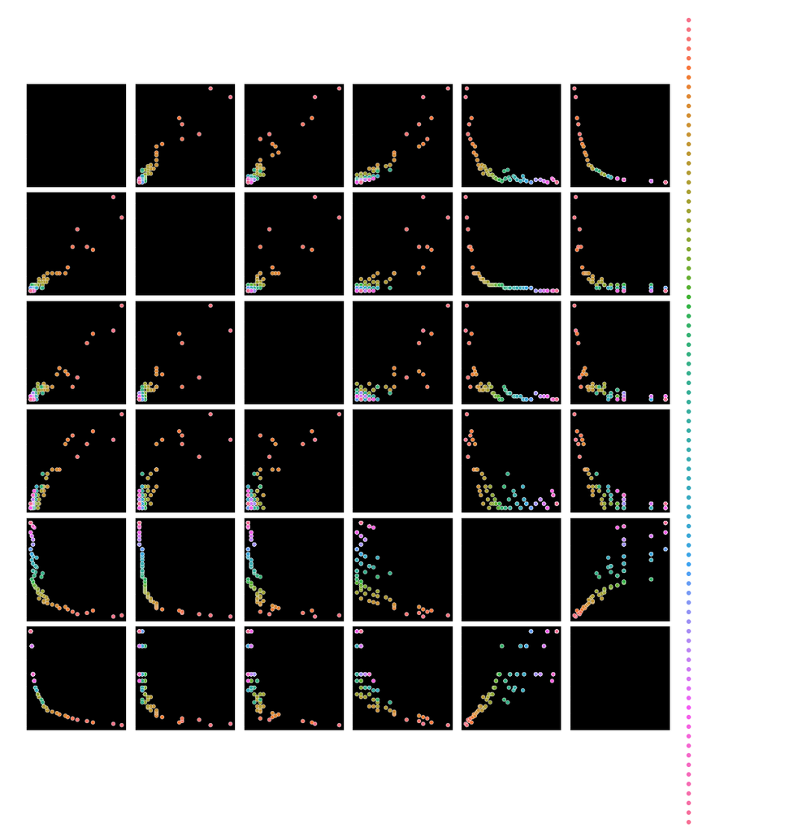

```python
sns.pairplot(Medals, hue="Team/NOC", height = 2.5)
```

## Hypothesis:The number of medals won in a previous Olympics can predict the country most likely to have won the medals

### examining historical medal data

```python
X = hist_med.drop(columns = 'Country')
y = hist_med['Country']
model = DecisionTreeClassifier()
model.fit(X, y)

# testing theory
predictions = model.predict([ [2002, 572, 780, 650], [4, 3, 0, 1] ])
predictions
```

```
array(['Germany (includes W but not E.Germany)', 'Mozambique'],
      dtype=object)
```

#### so we can do it, but is it accurate?

```python
from sklearn.metrics import accuracy_score
X = hist_med.drop(columns =['Country'])
y = hist_med['Country']
X_train, X_test, y_train, y_test = train_test_split(X, y, test_size = 0.25)
```

#### Checking the accuracy at 75,25

```python
model2 = DecisionTreeClassifier()
model2.fit(X_train, y_train)

predictions = model.predict(X_test)
score = accuracy_score(y_test, predictions)
score
```

```
0.7352941176470589
```

Note: The Historical Medal Data set is the accrued medal count over the 26 years the Summer Olympics had been held when the database was assembled. This gives us two options for finding a useful model. 1- Finding the average of the medals won over the 26 years included or 2- Multiplying the medals won in the most recent year by 26 as an estimate of how many medals are expected over 26 years. We examined both options to evaluate performance of the models.

#### avg medals per country

```python
def divide_by_26_games(number):
    return number/26

# executing the function
hist_med_avg  = hist_med[['Total', 'Golds','Silvers', 'Bronzes']].apply(divide_by_26_games)

hist_med_avg
```

|  | Total | Golds | Silvers | Bronzes |
| --- | --- | --- | --- | --- |
| 0 | 88.346154 | 35.769231 | 28.000000 | 24.576923 |
| 1 | 38.846154 | 15.192308 | 12.269231 | 11.384615 |
| 2 | 32.730769 | 9.500000 | 10.923077 | 12.307692 |
| 3 | 27.461538 | 7.961538 | 9.807692 | 9.692308 |
| 4 | 24.538462 | 7.384615 | 8.153846 | 9.000000 |
| ... | ... | ... | ... | ... |
| 129 | 0.038462 | 0.000000 | 0.038462 | 0.000000 |
| 130 | 0.038462 | 0.000000 | 0.000000 | 0.038462 |
| 131 | 0.038462 | 0.000000 | 0.038462 | 0.000000 |
| 132 | 0.038462 | 0.038462 | 0.000000 | 0.000000 |
| 133 | 0.038462 | 0.000000 | 0.038462 | 0.000000 |

134 rows × 4 columns

#### multiply current medals by 26

```python
def multiply_by_26_games(number):
    return number *26
#executing the function
Medals_Multiplied = Medals[['Total', 'Gold', 'Silver', 'Bronze']].apply(multiply_by_26_games)
Medals_Multiplied
```

|  | Total | Gold | Silver | Bronze |
| --- | --- | --- | --- | --- |
| 0 | 1820 | 832 | 572 | 416 |
| 1 | 2002 | 650 | 780 | 572 |
| 2 | 1040 | 546 | 182 | 312 |
| 3 | 1248 | 390 | 468 | 390 |
| 4 | 936 | 390 | 104 | 442 |
| ... | ... | ... | ... | ... |
| 80 | 26 | 0 | 0 | 26 |
| 81 | 26 | 0 | 0 | 26 |
| 82 | 26 | 0 | 0 | 26 |
| 83 | 26 | 0 | 0 | 26 |
| 84 | 26 | 0 | 0 | 26 |

85 rows × 4 columns

## Can the number of medals won in an Olympics predict the country most likely to have won the medals?

```python
X_Medals = Medals_Multiplied
y_Medals = Medals['Team/NOC']
model_Medals_Multiplied = DecisionTreeClassifier()
model_Medals_Multiplied.fit(X_Medals, y_Medals)

# testing theory
predictions = model_Medals_Multiplied.predict([ [77,22,30,25], [4, 3, 0, 1] ])
predictions
```

```
array(['Belgium', 'Jordan'], dtype=object)
```

```python
X = hist_med_avg
y = hist_med['Country']
model = DecisionTreeClassifier()
model.fit(X, y)

# testing theory
predictions = model.predict([ [77, 22, 30, 25], [4, 3, 0, 1] ])
predictions
```

```
array(['USA', 'Armenia'], dtype=object)
```

## so we can do it, but is it accurate?

## Checking the accuracy at 75,25

```python
from sklearn.metrics import accuracy_score

# Training the Medals_Multiplied set
X_Medals_train, X_Medals_test, y_Medals_train, y_Medals_test = train_test_split(X_Medals, y_Medals, test_size = 0.25)

model_Medals_Multiplied.fit(X_Medals_train, y_Medals_train)

predictions = model_Medals_Multiplied.predict(X_Medals_test)

# examing the accuracy score
score = accuracy_score(y_Medals_test, predictions)
score
```

```
0.0
```

```python
# Training the Historical Medals averaged by years
X_train, X_test, y_train, y_test = train_test_split(X, y, test_size = 0.25)
model2 = DecisionTreeClassifier()
model2.fit(X_train, y_train)

predictions = model.predict(X_test)

# examing the accuracy score
score = accuracy_score(y_test, predictions)
score
```

```
0.8235294117647058
```

### Accuracy is questionable for both models, but let's investigate what happens with the entire new Medals list as the prediction data

```python
List_medals = Medals_Multiplied.values.tolist()
List_medals
```

```
[[1820, 832, 572, 416],
 [2002, 650, 780, 572],
 [1040, 546, 182, 312],
 [1248, 390, 468, 390],
 [936, 390, 104, 442],
 [1378, 364, 546, 468],
 [832, 208, 208, 416],
 [650, 156, 260, 234],
 [780, 156, 234, 390],
 [598, 156, 208, 234],
 [494, 156, 104, 234],
 [390, 156, 104, 130],
 [312, 130, 78, 104],
 [312, 104, 130, 78],
 [390, 104, 78, 208],
```

[output cut: 70 more lines]

### Multiplied Medals prediction

```python
model_Medals_Multiplied = DecisionTreeClassifier()
model_Medals_Multiplied.fit(X_Medals_train, y_Medals_train)

# testing theory
predictions = model_Medals_Multiplied.predict(List_medals)
predictions
```

```
array(["People's Republic of China", 'United States of America',
       'Netherlands', "People's Republic of China", 'Australia', 'ROC',
       'Germany', 'France', 'Italy', 'Netherlands', 'Republic of Korea',
       'New Zealand', 'Hungary', 'Hungary', 'Brazil', 'Czech Republic',
       'Canada', 'Hungary', 'Chinese Taipei', 'Croatia', 'Ecuador',
       'Chinese Taipei', 'Georgia', 'Denmark', 'Norway', 'Denmark',
       'Islamic Republic of Iran', 'Islamic Republic of Iran', 'Ecuador',
       'Greece', 'Greece', 'Ecuador', 'Ecuador', 'Serbia', 'Romania',
       'Romania', 'Serbia', 'Kenya', 'Hong Kong, China',
       'Hong Kong, China', 'Hong Kong, China', 'Serbia', 'Austria',
       'Austria', 'Belgium', 'Belgium', 'Belgium', 'Philippines',
       'Philippines', 'Turkey', 'Ireland', 'Ireland', 'Estonia',
       'Estonia', 'Estonia', 'Estonia', 'Bermuda', 'Bermuda', 'Bermuda',
       'Bermuda', 'Colombia', 'Colombia', 'Colombia', 'Colombia', 'India',
       'India', 'India', 'Bulgaria', 'Bulgaria', 'Bulgaria', 'Jordan',
       'Jordan', 'Jordan', 'Jordan', 'Kazakhstan', 'Azerbaijan',
       'Azerbaijan', 'Azerbaijan', 'Argentina', 'Argentina', 'Argentina',
       'Argentina', 'Argentina', 'Argentina', 'Argentina'], dtype=object)
```

### Averaged Historical Medals

```python
model = DecisionTreeClassifier()
model.fit(X_train, y_train)

# testing theory
predictions = model.predict(List_medals)
predictions
```

```
array(['USA', 'USA', 'USA', 'USA', 'USA', 'USA', 'USA', 'USA', 'USA',
       'USA', 'USA', 'USA', 'USA', 'USA', 'USA', 'USA', 'USA', 'USA',
       'USA', 'USA', 'Zimbabwe', 'USA', 'USA', 'USA', 'USA', 'USA', 'USA',
       'USA', 'Zimbabwe', 'Mozambique', 'Mozambique',
       'United Arab Emirates', 'United Arab Emirates', 'USA', 'Zimbabwe',
       'Zimbabwe', 'USA', 'USA', 'Zimbabwe', 'Zimbabwe', 'Zimbabwe',
       'USA', 'USA', 'USA', 'USA', 'USA', 'USA', 'Zimbabwe', 'Zimbabwe',
       'Mozambique', 'Mozambique', 'Mozambique', 'Mozambique',
       'Mozambique', 'Mozambique', 'Mozambique', 'United Arab Emirates',
       'United Arab Emirates', 'United Arab Emirates',
       'United Arab Emirates', 'Namibia', 'Namibia', 'Namibia', 'Namibia',
       'Namibia', 'Namibia', 'Namibia', 'Namibia', 'Namibia', 'Namibia',
       'Namibia', 'Namibia', 'Namibia', 'Namibia', 'British West Indies',
       'British West Indies', 'British West Indies',
       'British West Indies', 'British West Indies',
       'British West Indies', 'British West Indies',
       'British West Indies', 'British West Indies',
       'British West Indies', 'British West Indies'], dtype=object)
```

## ❄ Dayana ❄

## 🐍 Python imports 🐍

### 🗃 File processing

```python
import glob
import os.path
import matplotlib.pyplot as plt
import numpy as np
import pandas as pd
```

### ⚠ Warning messages

```python
import warnings
```

### 🎨 Visualization

```python
import numpy as np
import pandas as pd
import matplotlib.pyplot as plt
import seaborn as sns
from sklearn.tree import DecisionTreeClassifier
```

## 📁 Data processing 📁

**🔗 Show links**

[figure not shown]

https://stackoverflow.com/questions/66214951/how-to-deal-with-warning-workbook-contains-no-default-style-apply-openpyxls

### 🍃 Extract

Store each excel file as a DataFrame in a dictionary `dfs`

```python
path = "../../data/"
# files = glob.glob("../../data/*.xlsx")
files = glob.glob(path + "*.xlsx")
dfs = {}

for file in files:
    file_name = os.path.splitext(file)[0].replace(path, "")
    with warnings.catch_warnings(record=True):
        warnings.simplefilter("always")
        df = pd.read_excel(file)
    dfs[file_name] = df
```

### 💧🔥 Transform

### 🍵 Load

#### 📝 Example: How to get a DataFrame from the `dfs` dictionary

```python
type(dfs)
```

```
dict
```

```python
dfs.keys()
```

```
dict_keys(['Athletes', 'Coaches', 'EntriesGender', 'Medals', 'Teams'])
```

```python
type(dfs["Medals"])
```

```
pandas.core.frame.DataFrame
```

```python
Med = dfs["Medals"]
Med
```

|  | Rank | Team/NOC | Gold | Silver | Bronze | Total | Rank by Total |
| --- | --- | --- | --- | --- | --- | --- | --- |
| 0 | 1 | People's Republic of China | 32 | 22 | 16 | 70 | 2 |
| 1 | 2 | United States of America | 25 | 30 | 22 | 77 | 1 |
| 2 | 3 | Japan | 21 | 7 | 12 | 40 | 5 |
| 3 | 4 | Great Britain | 15 | 18 | 15 | 48 | 4 |
| 4 | 5 | Australia | 15 | 4 | 17 | 36 | 6 |
| ... | ... | ... | ... | ... | ... | ... | ... |
| 80 | 79 | Finland | 0 | 0 | 1 | 1 | 71 |
| 81 | 79 | Ghana | 0 | 0 | 1 | 1 | 71 |
| 82 | 79 | Kuwait | 0 | 0 | 1 | 1 | 71 |
| 83 | 79 | Malaysia | 0 | 0 | 1 | 1 | 71 |
| 84 | 79 | Syrian Arab Republic | 0 | 0 | 1 | 1 | 71 |

85 rows × 7 columns

```python
Med.describe()
```

|  | Rank | Gold | Silver | Bronze | Total | Rank by Total |
| --- | --- | --- | --- | --- | --- | --- |
| count | 85.000000 | 85.000000 | 85.000000 | 85.000000 | 85.000000 | 85.000000 |
| mean | 42.211765 | 2.847059 | 2.823529 | 3.376471 | 9.047059 | 38.282353 |
| std | 23.951386 | 5.432499 | 5.043092 | 4.837789 | 14.491299 | 21.777343 |
| min | 1.000000 | 0.000000 | 0.000000 | 0.000000 | 1.000000 | 1.000000 |
| 25% | 22.000000 | 0.000000 | 0.000000 | 1.000000 | 2.000000 | 22.000000 |
| 50% | 43.000000 | 1.000000 | 1.000000 | 1.000000 | 3.000000 | 39.000000 |
| 75% | 61.000000 | 2.000000 | 3.000000 | 4.000000 | 8.000000 | 60.000000 |
| max | 79.000000 | 32.000000 | 30.000000 | 22.000000 | 77.000000 | 71.000000 |

```python
Gend = dfs["EntriesGender"]
Gend
```

|  | Discipline | Female | Male | Total |
| --- | --- | --- | --- | --- |
| 0 | 3x3 Basketball | 32 | 32 | 64 |
| 1 | Archery | 64 | 64 | 128 |
| 2 | Artistic Gymnastics | 98 | 98 | 196 |
| 3 | Artistic Swimming | 105 | 0 | 105 |
| 4 | Athletics | 969 | 1072 | 2041 |
| 5 | Badminton | 86 | 87 | 173 |
| 6 | Baseball/Softball | 90 | 144 | 234 |
| 7 | Basketball | 144 | 144 | 288 |
| 8 | Beach Volleyball | 48 | 48 | 96 |
| 9 | Boxing | 102 | 187 | 289 |
| 10 | Canoe Slalom | 41 | 41 | 82 |
| 11 | Canoe Sprint | 123 | 126 | 249 |
| 12 | Cycling BMX Freestyle | 10 | 9 | 19 |
| 13 | Cycling BMX Racing | 24 | 24 | 48 |
| 14 | Cycling Mountain Bike | 38 | 38 | 76 |
| 15 | Cycling Road | 70 | 131 | 201 |
| 16 | Cycling Track | 90 | 99 | 189 |
| 17 | Diving | 72 | 71 | 143 |
| 18 | Equestrian | 73 | 125 | 198 |
| 19 | Fencing | 107 | 108 | 215 |
| 20 | Football | 264 | 344 | 608 |
| 21 | Golf | 60 | 60 | 120 |
| 22 | Handball | 168 | 168 | 336 |
| 23 | Hockey | 192 | 192 | 384 |
| 24 | Judo | 192 | 201 | 393 |
| 25 | Karate | 40 | 42 | 82 |
| 26 | Marathon Swimming | 25 | 25 | 50 |
| 27 | Modern Pentathlon | 36 | 36 | 72 |
| 28 | Rhythmic Gymnastics | 96 | 0 | 96 |
| 29 | Rowing | 257 | 265 | 522 |
| 30 | Rugby Sevens | 146 | 151 | 297 |
| 31 | Sailing | 175 | 175 | 350 |
| 32 | Shooting | 178 | 178 | 356 |
| 33 | Skateboarding | 40 | 40 | 80 |
| 34 | Sport Climbing | 20 | 20 | 40 |
| 35 | Surfing | 20 | 20 | 40 |
| 36 | Swimming | 361 | 418 | 779 |
| 37 | Table Tennis | 86 | 86 | 172 |
| 38 | Taekwondo | 65 | 65 | 130 |
| 39 | Tennis | 94 | 97 | 191 |
| 40 | Trampoline Gymnastics | 16 | 16 | 32 |
| 41 | Triathlon | 55 | 55 | 110 |
| 42 | Volleyball | 144 | 144 | 288 |
| 43 | Water Polo | 122 | 146 | 268 |
| 44 | Weightlifting | 98 | 99 | 197 |
| 45 | Wrestling | 96 | 193 | 289 |

```python
Gend.describe()
```

|  | Female | Male | Total |
| --- | --- | --- | --- |
| count | 46.000000 | 46.000000 | 46.00000 |
| mean | 118.086957 | 127.913043 | 246.00000 |
| std | 147.169717 | 166.900746 | 312.46134 |
| min | 10.000000 | 0.000000 | 19.00000 |
| 25% | 42.750000 | 40.250000 | 85.50000 |
| 50% | 90.000000 | 97.500000 | 190.00000 |
| 75% | 138.750000 | 149.750000 | 288.75000 |
| max | 969.000000 | 1072.000000 | 2041.00000 |

```python
Aths = dfs["Athletes"]
Aths
```

|  | Name | NOC | Discipline |
| --- | --- | --- | --- |
| 0 | AALERUD Katrine | Norway | Cycling Road |
| 1 | ABAD Nestor | Spain | Artistic Gymnastics |
| 2 | ABAGNALE Giovanni | Italy | Rowing |
| 3 | ABALDE Alberto | Spain | Basketball |
| 4 | ABALDE Tamara | Spain | Basketball |
| ... | ... | ... | ... |
| 11080 | ZWICKER Martin Detlef | Germany | Hockey |
| 11081 | ZWOLINSKA Klaudia | Poland | Canoe Slalom |
| 11082 | ZYKOVA Yulia | ROC | Shooting |
| 11083 | ZYUZINA Ekaterina | ROC | Sailing |
| 11084 | ZYZANSKA Sylwia | Poland | Archery |

11085 rows × 3 columns

```python
Aths.describe()
```

|  | Name | NOC | Discipline |
| --- | --- | --- | --- |
| count | 11085 | 11085 | 11085 |
| unique | 11062 | 206 | 46 |
| top | CHEN Yang | United States of America | Athletics |
| freq | 2 | 615 | 2068 |

```python
Teams = dfs['Teams']
Teams
```

|  | Name | Discipline | NOC | Event |
| --- | --- | --- | --- | --- |
| 0 | Belgium | 3x3 Basketball | Belgium | Men |
| 1 | China | 3x3 Basketball | People's Republic of China | Men |
| 2 | China | 3x3 Basketball | People's Republic of China | Women |
| 3 | France | 3x3 Basketball | France | Women |
| 4 | Italy | 3x3 Basketball | Italy | Women |
| ... | ... | ... | ... | ... |
| 738 | South Africa | Water Polo | South Africa | Women |
| 739 | Spain | Water Polo | Spain | Men |
| 740 | Spain | Water Polo | Spain | Women |
| 741 | United States | Water Polo | United States of America | Men |
| 742 | United States | Water Polo | United States of America | Women |

743 rows × 4 columns

```python
Teams.describe()
```

|  | Name | Discipline | NOC | Event |
| --- | --- | --- | --- | --- |
| count | 743 | 743 | 743 | 743 |
| unique | 146 | 20 | 84 | 36 |
| top | Japan | Swimming | Japan | Men |
| freq | 45 | 113 | 48 | 120 |

```python
Coach = dfs['Coaches']
Coach
```

|  | Name | NOC | Discipline | Event |
| --- | --- | --- | --- | --- |
| 0 | ABDELMAGID Wael | Egypt | Football | NaN |
| 1 | ABE Junya | Japan | Volleyball | NaN |
| 2 | ABE Katsuhiko | Japan | Basketball | NaN |
| 3 | ADAMA Cherif | Côte d'Ivoire | Football | NaN |
| 4 | AGEBA Yuya | Japan | Volleyball | NaN |
| ... | ... | ... | ... | ... |
| 389 | ZAMORA PEDREIRA Javier | Spain | Basketball | NaN |
| 390 | ZAMPIERI Francesca | Liechtenstein | Artistic Swimming | Duet |
| 391 | ZHANG Xiaohuan | People's Republic of China | Artistic Swimming | NaN |
| 392 | ZIJP Simon | Netherlands | Hockey | NaN |
| 393 | ZONDI Nkuliso | South Africa | Hockey | Women |

394 rows × 4 columns

```python
Coach.describe()
```

|  | Name | NOC | Discipline | Event |
| --- | --- | --- | --- | --- |
| count | 394 | 394 | 394 | 249 |
| unique | 381 | 61 | 9 | 6 |
| top | REQUENA PERICAS Judit | Japan | Basketball | Men |
| freq | 2 | 35 | 74 | 94 |

## ❄ Visualizations ❄

[figure not shown]

```python
Gend.plot(x="Discipline", y=["Female","Male"], kind="bar", figsize=(15,5))

# print bar graph
plt.show()
```

[figure not shown]

```python
Med.plot(x="Team/NOC", y=["Gold", "Silver","Bronze"], kind="bar", figsize=(20,5))

# print bar graph
plt.show()
```